# 2023年度报告-净资产收益率

使用em的业绩报告数据。

## 净资产收益率

### 全市场ROE

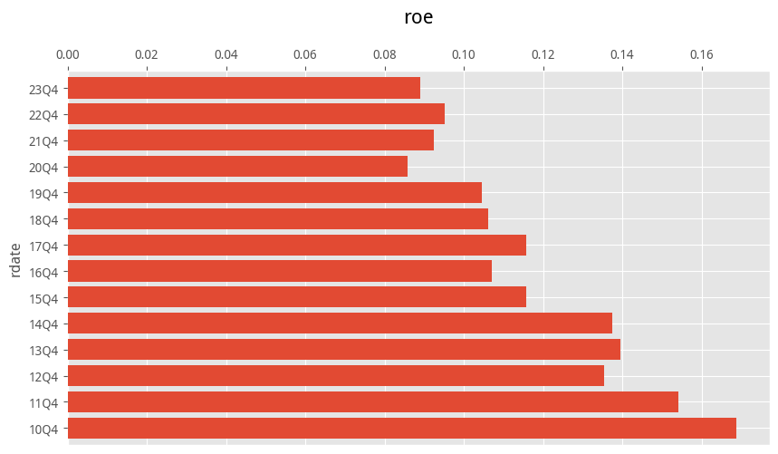

- ROE总体是下降的，2020年疫情开始急剧下降，但后两年有所回升，但2023年明显下降。

### ROE排名前20

|  | mean | median | min | max |
| --- | --- | --- | --- | --- |
| 0 | [三一重能](https://data.eastmoney.com/stockdata/688349.html) | [键邦股份](https://data.eastmoney.com/stockdata/603285.html) | [艾罗能源](https://data.eastmoney.com/stockdata/688717.html) | [骏创科技](https://data.eastmoney.com/stockdata/833533.html) |
| 1 | [骏创科技](https://data.eastmoney.com/stockdata/833533.html) | [敷尔佳](https://data.eastmoney.com/stockdata/301371.html) | [德业股份](https://data.eastmoney.com/stockdata/605117.html) | [卓锦股份](https://data.eastmoney.com/stockdata/688701.html) |
| 2 | [艾罗能源](https://data.eastmoney.com/stockdata/688717.html) | [星宸科技](https://data.eastmoney.com/stockdata/301536.html) | [联域股份](https://data.eastmoney.com/stockdata/001326.html) | [三一重能](https://data.eastmoney.com/stockdata/688349.html) |
| 3 | [敷尔佳](https://data.eastmoney.com/stockdata/301371.html) | [蕾奥规划](https://data.eastmoney.com/stockdata/300989.html) | [公牛集团](https://data.eastmoney.com/stockdata/603195.html) | [中英科技](https://data.eastmoney.com/stockdata/300936.html) |
| 4 | [中英科技](https://data.eastmoney.com/stockdata/300936.html) | [艾罗能源](https://data.eastmoney.com/stockdata/688717.html) | [亿联网络](https://data.eastmoney.com/stockdata/300628.html) | [海南机场](https://data.eastmoney.com/stockdata/600515.html) |
| 5 | [纳睿雷达](https://data.eastmoney.com/stockdata/688522.html) | [贝泰妮](https://data.eastmoney.com/stockdata/300957.html) | [北自科技](https://data.eastmoney.com/stockdata/603082.html) | [若羽臣](https://data.eastmoney.com/stockdata/003010.html) |
| 6 | [曼恩斯特](https://data.eastmoney.com/stockdata/301325.html) | [曼恩斯特](https://data.eastmoney.com/stockdata/301325.html) | [绿联科技](https://data.eastmoney.com/stockdata/301606.html) | [致远新能](https://data.eastmoney.com/stockdata/300985.html) |
| 7 | [致远新能](https://data.eastmoney.com/stockdata/300985.html) | [思泰克](https://data.eastmoney.com/stockdata/301568.html) | [武汉蓝电](https://data.eastmoney.com/stockdata/830779.html) | [光库科技](https://data.eastmoney.com/stockdata/300620.html) |
| 8 | [卓兆点胶](https://data.eastmoney.com/stockdata/873726.html) | [公牛集团](https://data.eastmoney.com/stockdata/603195.html) | [贵州茅台](https://data.eastmoney.com/stockdata/600519.html) | [九丰能源](https://data.eastmoney.com/stockdata/605090.html) |
| 9 | [小熊电器](https://data.eastmoney.com/stockdata/002959.html) | [博硕科技](https://data.eastmoney.com/stockdata/300951.html) | [宝立食品](https://data.eastmoney.com/stockdata/603170.html) | [纳睿雷达](https://data.eastmoney.com/stockdata/688522.html) |
| 10 | [卓锦股份](https://data.eastmoney.com/stockdata/688701.html) | [鼎智科技](https://data.eastmoney.com/stockdata/873593.html) | [达梦数据](https://data.eastmoney.com/stockdata/688692.html) | [小熊电器](https://data.eastmoney.com/stockdata/002959.html) |
| 11 | [昱能科技](https://data.eastmoney.com/stockdata/688348.html) | [麦澜德](https://data.eastmoney.com/stockdata/688273.html) | [力聚热能](https://data.eastmoney.com/stockdata/603391.html) | [中再资环](https://data.eastmoney.com/stockdata/600217.html) |
| 12 | [九丰能源](https://data.eastmoney.com/stockdata/605090.html) | [万邦医药](https://data.eastmoney.com/stockdata/301520.html) | [华利集团](https://data.eastmoney.com/stockdata/300979.html) | [海信家电](https://data.eastmoney.com/stockdata/000921.html) |
| 13 | [中科蓝讯](https://data.eastmoney.com/stockdata/688332.html) | [观想科技](https://data.eastmoney.com/stockdata/301213.html) | [润本股份](https://data.eastmoney.com/stockdata/603193.html) | [航锦科技](https://data.eastmoney.com/stockdata/000818.html) |
| 14 | [安克创新](https://data.eastmoney.com/stockdata/300866.html) | [尤安设计](https://data.eastmoney.com/stockdata/300983.html) | [键邦股份](https://data.eastmoney.com/stockdata/603285.html) | [宁波东力](https://data.eastmoney.com/stockdata/002164.html) |
| 15 | [键邦股份](https://data.eastmoney.com/stockdata/603285.html) | [卓兆点胶](https://data.eastmoney.com/stockdata/873726.html) | [美的集团](https://data.eastmoney.com/stockdata/000333.html) | [冰川网络](https://data.eastmoney.com/stockdata/300533.html) |
| 16 | [万邦医药](https://data.eastmoney.com/stockdata/301520.html) | [南大环境](https://data.eastmoney.com/stockdata/300864.html) | [飞科电器](https://data.eastmoney.com/stockdata/603868.html) | [赛维时代](https://data.eastmoney.com/stockdata/301381.html) |
| 17 | [美腾科技](https://data.eastmoney.com/stockdata/688420.html) | [泰鹏智能](https://data.eastmoney.com/stockdata/873132.html) | [东鹏饮料](https://data.eastmoney.com/stockdata/605499.html) | [安克创新](https://data.eastmoney.com/stockdata/300866.html) |
| 18 | [科瑞思](https://data.eastmoney.com/stockdata/301314.html) | [昱能科技](https://data.eastmoney.com/stockdata/688348.html) | [物产环能](https://data.eastmoney.com/stockdata/603071.html) | [概伦电子](https://data.eastmoney.com/stockdata/688206.html) |
| 19 | [金迪克](https://data.eastmoney.com/stockdata/688670.html) | [欧克科技](https://data.eastmoney.com/stockdata/001223.html) | [西典新能](https://data.eastmoney.com/stockdata/603312.html) | [思泉新材](https://data.eastmoney.com/stockdata/301489.html) |

### 总体变化

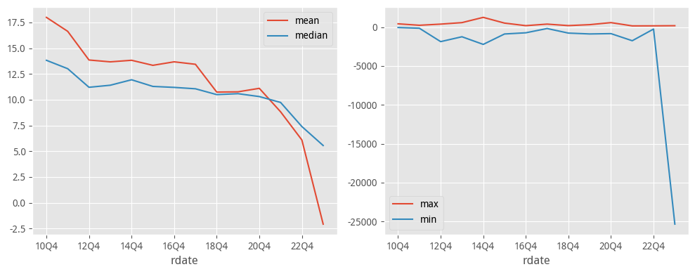

### 每年前20

| rdate | 10Q4 | 11Q4 | 12Q4 | 13Q4 | 14Q4 | 15Q4 | 16Q4 | 17Q4 | 18Q4 | 19Q4 | 20Q4 | 21Q4 | 22Q4 | 23Q4 |
| --- | --- | --- | --- | --- | --- | --- | --- | --- | --- | --- | --- | --- | --- | --- |
| 0 | [海南机场](https://data.eastmoney.com/stockdata/600515.html) | [冰川网络](https://data.eastmoney.com/stockdata/300533.html) | [光库科技](https://data.eastmoney.com/stockdata/300620.html) | [卓锦股份](https://data.eastmoney.com/stockdata/688701.html) | [骏创科技](https://data.eastmoney.com/stockdata/833533.html) | [中英科技](https://data.eastmoney.com/stockdata/300936.html) | [南新制药](https://data.eastmoney.com/stockdata/688189.html) | [致远新能](https://data.eastmoney.com/stockdata/300985.html) | [敷尔佳](https://data.eastmoney.com/stockdata/301371.html) | [纳睿雷达](https://data.eastmoney.com/stockdata/688522.html) | [三一重能](https://data.eastmoney.com/stockdata/688349.html) | [宏达股份](https://data.eastmoney.com/stockdata/600331.html) | [艾罗能源](https://data.eastmoney.com/stockdata/688717.html) | [华控赛格](https://data.eastmoney.com/stockdata/000068.html) |
| 1 | [海信家电](https://data.eastmoney.com/stockdata/000921.html) | [电魂网络](https://data.eastmoney.com/stockdata/603258.html) | [明德生物](https://data.eastmoney.com/stockdata/002932.html) | [观想科技](https://data.eastmoney.com/stockdata/301213.html) | [若羽臣](https://data.eastmoney.com/stockdata/003010.html) | [九丰能源](https://data.eastmoney.com/stockdata/605090.html) | [仙乐健康](https://data.eastmoney.com/stockdata/300791.html) | [光峰科技](https://data.eastmoney.com/stockdata/688007.html) | [昱能科技](https://data.eastmoney.com/stockdata/688348.html) | [概伦电子](https://data.eastmoney.com/stockdata/688206.html) | [宁波东力](https://data.eastmoney.com/stockdata/002164.html) | [热景生物](https://data.eastmoney.com/stockdata/688068.html) | [九安医疗](https://data.eastmoney.com/stockdata/002432.html) | [石英股份](https://data.eastmoney.com/stockdata/603688.html) |
| 2 | [航锦科技](https://data.eastmoney.com/stockdata/000818.html) | [峆一药业](https://data.eastmoney.com/stockdata/430478.html) | [电魂网络](https://data.eastmoney.com/stockdata/603258.html) | [天永智能](https://data.eastmoney.com/stockdata/603895.html) | [中再资环](https://data.eastmoney.com/stockdata/600217.html) | [小熊电器](https://data.eastmoney.com/stockdata/002959.html) | [泰鹏智能](https://data.eastmoney.com/stockdata/873132.html) | [国能日新](https://data.eastmoney.com/stockdata/301162.html) | [科瑞思](https://data.eastmoney.com/stockdata/301314.html) | [中科蓝讯](https://data.eastmoney.com/stockdata/688332.html) | [金迪克](https://data.eastmoney.com/stockdata/688670.html) | [湖北宜化](https://data.eastmoney.com/stockdata/000422.html) | [融捷股份](https://data.eastmoney.com/stockdata/002192.html) | [中基健康](https://data.eastmoney.com/stockdata/000972.html) |
| 3 | [中航产融](https://data.eastmoney.com/stockdata/600705.html) | [京基智农](https://data.eastmoney.com/stockdata/000048.html) | [全志科技](https://data.eastmoney.com/stockdata/300458.html) | [西藏珠峰](https://data.eastmoney.com/stockdata/600338.html) | [思泉新材](https://data.eastmoney.com/stockdata/301489.html) | [赛维时代](https://data.eastmoney.com/stockdata/301381.html) | [锦好医疗](https://data.eastmoney.com/stockdata/872925.html) | [四川金顶](https://data.eastmoney.com/stockdata/600678.html) | [多瑞医药](https://data.eastmoney.com/stockdata/301075.html) | [航天软件](https://data.eastmoney.com/stockdata/688562.html) | [卓兆点胶](https://data.eastmoney.com/stockdata/873726.html) | [东方生物](https://data.eastmoney.com/stockdata/688298.html) | [天华新能](https://data.eastmoney.com/stockdata/300390.html) | [澳洋健康](https://data.eastmoney.com/stockdata/002172.html) |
| 4 | [利君股份](https://data.eastmoney.com/stockdata/002651.html) | [天润科技](https://data.eastmoney.com/stockdata/430564.html) | [浩物股份](https://data.eastmoney.com/stockdata/000757.html) | [博睿数据](https://data.eastmoney.com/stockdata/688229.html) | [喜悦智行](https://data.eastmoney.com/stockdata/301198.html) | [安克创新](https://data.eastmoney.com/stockdata/300866.html) | [中胤时尚](https://data.eastmoney.com/stockdata/300901.html) | [康华生物](https://data.eastmoney.com/stockdata/300841.html) | [曼恩斯特](https://data.eastmoney.com/stockdata/301325.html) | [曼恩斯特](https://data.eastmoney.com/stockdata/301325.html) | [中红医疗](https://data.eastmoney.com/stockdata/300981.html) | [中远海控](https://data.eastmoney.com/stockdata/601919.html) | [明德生物](https://data.eastmoney.com/stockdata/002932.html) | [银宝山新](https://data.eastmoney.com/stockdata/002786.html) |
| 5 | [金杯汽车](https://data.eastmoney.com/stockdata/600609.html) | [丸美股份](https://data.eastmoney.com/stockdata/603983.html) | [鑫汇科](https://data.eastmoney.com/stockdata/831167.html) | [电魂网络](https://data.eastmoney.com/stockdata/603258.html) | [赛腾股份](https://data.eastmoney.com/stockdata/603283.html) | [沪光股份](https://data.eastmoney.com/stockdata/605333.html) | [迎丰股份](https://data.eastmoney.com/stockdata/605055.html) | [博硕科技](https://data.eastmoney.com/stockdata/300951.html) | [盛美上海](https://data.eastmoney.com/stockdata/688082.html) | [灿勤科技](https://data.eastmoney.com/stockdata/688182.html) | [獐子岛](https://data.eastmoney.com/stockdata/002069.html) | [重庆啤酒](https://data.eastmoney.com/stockdata/600132.html) | [天齐锂业](https://data.eastmoney.com/stockdata/002466.html) | [重庆啤酒](https://data.eastmoney.com/stockdata/600132.html) |
| 6 | [神州数码](https://data.eastmoney.com/stockdata/000034.html) | [盛和资源](https://data.eastmoney.com/stockdata/600392.html) | [艾德生物](https://data.eastmoney.com/stockdata/300685.html) | [川恒股份](https://data.eastmoney.com/stockdata/002895.html) | [天阳科技](https://data.eastmoney.com/stockdata/300872.html) | [品渥食品](https://data.eastmoney.com/stockdata/300892.html) | [小熊电器](https://data.eastmoney.com/stockdata/002959.html) | [美畅股份](https://data.eastmoney.com/stockdata/300861.html) | [万邦医药](https://data.eastmoney.com/stockdata/301520.html) | [美腾科技](https://data.eastmoney.com/stockdata/688420.html) | [义翘神州](https://data.eastmoney.com/stockdata/301047.html) | [倍益康](https://data.eastmoney.com/stockdata/870199.html) | [仁智股份](https://data.eastmoney.com/stockdata/002629.html) | [顾地科技](https://data.eastmoney.com/stockdata/002694.html) |
| 7 | [福斯特](https://data.eastmoney.com/stockdata/603806.html) | [蓝思科技](https://data.eastmoney.com/stockdata/300433.html) | [汇顶科技](https://data.eastmoney.com/stockdata/603160.html) | [明德生物](https://data.eastmoney.com/stockdata/002932.html) | [英搏尔](https://data.eastmoney.com/stockdata/300681.html) | [美登科技](https://data.eastmoney.com/stockdata/838227.html) | [蕾奥规划](https://data.eastmoney.com/stockdata/300989.html) | [东芯股份](https://data.eastmoney.com/stockdata/688110.html) | [清研环境](https://data.eastmoney.com/stockdata/301288.html) | [敷尔佳](https://data.eastmoney.com/stockdata/301371.html) | [ST升达](https://data.eastmoney.com/stockdata/002259.html) | [中微半导](https://data.eastmoney.com/stockdata/688380.html) | [安旭生物](https://data.eastmoney.com/stockdata/688075.html) | [艾罗能源](https://data.eastmoney.com/stockdata/688717.html) |
| 8 | [海思科](https://data.eastmoney.com/stockdata/002653.html) | [晨曦航空](https://data.eastmoney.com/stockdata/300581.html) | [ST联络](https://data.eastmoney.com/stockdata/002280.html) | [华夏航空](https://data.eastmoney.com/stockdata/002928.html) | [值得买](https://data.eastmoney.com/stockdata/300785.html) | [善水科技](https://data.eastmoney.com/stockdata/301190.html) | [新赣江](https://data.eastmoney.com/stockdata/873167.html) | [新赣江](https://data.eastmoney.com/stockdata/873167.html) | [丛麟科技](https://data.eastmoney.com/stockdata/688370.html) | [微导纳米](https://data.eastmoney.com/stockdata/688147.html) | [博拓生物](https://data.eastmoney.com/stockdata/688767.html) | [华洋赛车](https://data.eastmoney.com/stockdata/834058.html) | [江特电机](https://data.eastmoney.com/stockdata/002176.html) | [TCL智家](https://data.eastmoney.com/stockdata/002668.html) |
| 9 | [慈星股份](https://data.eastmoney.com/stockdata/300307.html) | [南大光电](https://data.eastmoney.com/stockdata/300346.html) | [京能热力](https://data.eastmoney.com/stockdata/002893.html) | [基蛋生物](https://data.eastmoney.com/stockdata/603387.html) | [奥特维](https://data.eastmoney.com/stockdata/688516.html) | [三态股份](https://data.eastmoney.com/stockdata/301558.html) | [安克创新](https://data.eastmoney.com/stockdata/300866.html) | [昀冢科技](https://data.eastmoney.com/stockdata/688260.html) | [昀冢科技](https://data.eastmoney.com/stockdata/688260.html) | [准油股份](https://data.eastmoney.com/stockdata/002207.html) | [威力传动](https://data.eastmoney.com/stockdata/300904.html) | [麦加芯彩](https://data.eastmoney.com/stockdata/603062.html) | [永兴材料](https://data.eastmoney.com/stockdata/002756.html) | [京基智农](https://data.eastmoney.com/stockdata/000048.html) |
| 10 | [四维图新](https://data.eastmoney.com/stockdata/002405.html) | [盛天网络](https://data.eastmoney.com/stockdata/300494.html) | [杰美特](https://data.eastmoney.com/stockdata/300868.html) | [吉比特](https://data.eastmoney.com/stockdata/603444.html) | [唐源电气](https://data.eastmoney.com/stockdata/300789.html) | [百诚医药](https://data.eastmoney.com/stockdata/301096.html) | [传智教育](https://data.eastmoney.com/stockdata/003032.html) | [中科星图](https://data.eastmoney.com/stockdata/688568.html) | [三态股份](https://data.eastmoney.com/stockdata/301558.html) | [星宸科技](https://data.eastmoney.com/stockdata/301536.html) | [英诺特](https://data.eastmoney.com/stockdata/688253.html) | [博拓生物](https://data.eastmoney.com/stockdata/688767.html) | [湖南裕能](https://data.eastmoney.com/stockdata/301358.html) | [高测股份](https://data.eastmoney.com/stockdata/688556.html) |
| 11 | [亚玛顿](https://data.eastmoney.com/stockdata/002623.html) | [智动力](https://data.eastmoney.com/stockdata/300686.html) | [金马游乐](https://data.eastmoney.com/stockdata/300756.html) | [兰卫医学](https://data.eastmoney.com/stockdata/301060.html) | [锦波生物](https://data.eastmoney.com/stockdata/832982.html) | [宁德时代](https://data.eastmoney.com/stockdata/300750.html) | [利元亨](https://data.eastmoney.com/stockdata/688499.html) | [捷强装备](https://data.eastmoney.com/stockdata/300875.html) | [思林杰](https://data.eastmoney.com/stockdata/688115.html) | [通行宝](https://data.eastmoney.com/stockdata/301339.html) | [安旭生物](https://data.eastmoney.com/stockdata/688075.html) | [智飞生物](https://data.eastmoney.com/stockdata/300122.html) | [重庆啤酒](https://data.eastmoney.com/stockdata/600132.html) | [欧晶科技](https://data.eastmoney.com/stockdata/001269.html) |
| 12 | [双星新材](https://data.eastmoney.com/stockdata/002585.html) | [晶盛机电](https://data.eastmoney.com/stockdata/300316.html) | [鼎信通讯](https://data.eastmoney.com/stockdata/603421.html) | [德创环保](https://data.eastmoney.com/stockdata/603177.html) | [爱迪特](https://data.eastmoney.com/stockdata/301580.html) | [卓胜微](https://data.eastmoney.com/stockdata/300782.html) | [中英科技](https://data.eastmoney.com/stockdata/300936.html) | [世华科技](https://data.eastmoney.com/stockdata/688093.html) | [魅视科技](https://data.eastmoney.com/stockdata/001229.html) | [丰茂股份](https://data.eastmoney.com/stockdata/301459.html) | [英科医疗](https://data.eastmoney.com/stockdata/300677.html) | [明德生物](https://data.eastmoney.com/stockdata/002932.html) | [盛新锂能](https://data.eastmoney.com/stockdata/002240.html) | [立霸股份](https://data.eastmoney.com/stockdata/603519.html) |
| 13 | [盛达资源](https://data.eastmoney.com/stockdata/000603.html) | [会畅通讯](https://data.eastmoney.com/stockdata/300578.html) | [贝达药业](https://data.eastmoney.com/stockdata/300558.html) | [同兴达](https://data.eastmoney.com/stockdata/002845.html) | [利通电子](https://data.eastmoney.com/stockdata/603629.html) | [奥特维](https://data.eastmoney.com/stockdata/688516.html) | [沪光股份](https://data.eastmoney.com/stockdata/605333.html) | [紫建电子](https://data.eastmoney.com/stockdata/301121.html) | [观想科技](https://data.eastmoney.com/stockdata/301213.html) | [清研环境](https://data.eastmoney.com/stockdata/301288.html) | [华宝新能](https://data.eastmoney.com/stockdata/301327.html) | [华宝新能](https://data.eastmoney.com/stockdata/301327.html) | [昂立教育](https://data.eastmoney.com/stockdata/600661.html) | [中炬高新](https://data.eastmoney.com/stockdata/600872.html) |
| 14 | [三诺生物](https://data.eastmoney.com/stockdata/300298.html) | [新华网](https://data.eastmoney.com/stockdata/603888.html) | [英维克](https://data.eastmoney.com/stockdata/002837.html) | [华如科技](https://data.eastmoney.com/stockdata/301302.html) | [水羊股份](https://data.eastmoney.com/stockdata/300740.html) | [天下秀](https://data.eastmoney.com/stockdata/600556.html) | [卓胜微](https://data.eastmoney.com/stockdata/300782.html) | [科威尔](https://data.eastmoney.com/stockdata/688551.html) | [宏英智能](https://data.eastmoney.com/stockdata/001266.html) | [创耀科技](https://data.eastmoney.com/stockdata/688259.html) | [晶华微](https://data.eastmoney.com/stockdata/688130.html) | [键邦股份](https://data.eastmoney.com/stockdata/603285.html) | [钧达股份](https://data.eastmoney.com/stockdata/002865.html) | [锦波生物](https://data.eastmoney.com/stockdata/832982.html) |
| 15 | [盛和资源](https://data.eastmoney.com/stockdata/600392.html) | [北方稀土](https://data.eastmoney.com/stockdata/600111.html) | [冰川网络](https://data.eastmoney.com/stockdata/300533.html) | [华恒生物](https://data.eastmoney.com/stockdata/688639.html) | [挖金客](https://data.eastmoney.com/stockdata/301380.html) | [科拓生物](https://data.eastmoney.com/stockdata/300858.html) | [立航科技](https://data.eastmoney.com/stockdata/603261.html) | [中南股份](https://data.eastmoney.com/stockdata/000717.html) | [嘉戎技术](https://data.eastmoney.com/stockdata/301148.html) | [宏英智能](https://data.eastmoney.com/stockdata/001266.html) | [田中精机](https://data.eastmoney.com/stockdata/300461.html) | [必易微](https://data.eastmoney.com/stockdata/688045.html) | [大全能源](https://data.eastmoney.com/stockdata/688303.html) | [嘉益股份](https://data.eastmoney.com/stockdata/301004.html) |
| 16 | [黑芝麻](https://data.eastmoney.com/stockdata/000716.html) | [飞科电器](https://data.eastmoney.com/stockdata/603868.html) | [地素时尚](https://data.eastmoney.com/stockdata/603587.html) | [光库科技](https://data.eastmoney.com/stockdata/300620.html) | [捷强装备](https://data.eastmoney.com/stockdata/300875.html) | [青矩技术](https://data.eastmoney.com/stockdata/836208.html) | [虹软科技](https://data.eastmoney.com/stockdata/688088.html) | [冠龙节能](https://data.eastmoney.com/stockdata/301151.html) | [奥来德](https://data.eastmoney.com/stockdata/688378.html) | [民和股份](https://data.eastmoney.com/stockdata/002234.html) | [奥泰生物](https://data.eastmoney.com/stockdata/688606.html) | [国航远洋](https://data.eastmoney.com/stockdata/833171.html) | [TCL智家](https://data.eastmoney.com/stockdata/002668.html) | [山西汾酒](https://data.eastmoney.com/stockdata/600809.html) |
| 17 | [南大光电](https://data.eastmoney.com/stockdata/300346.html) | [维宏股份](https://data.eastmoney.com/stockdata/300508.html) | [天娱数科](https://data.eastmoney.com/stockdata/002354.html) | [百甲科技](https://data.eastmoney.com/stockdata/835857.html) | [传智教育](https://data.eastmoney.com/stockdata/003032.html) | [奥飞数据](https://data.eastmoney.com/stockdata/300738.html) | [云里物里](https://data.eastmoney.com/stockdata/872374.html) | [纬德信息](https://data.eastmoney.com/stockdata/688171.html) | [海科新源](https://data.eastmoney.com/stockdata/301292.html) | [益生股份](https://data.eastmoney.com/stockdata/002458.html) | [圣湘生物](https://data.eastmoney.com/stockdata/688289.html) | [三元生物](https://data.eastmoney.com/stockdata/301206.html) | [赣锋锂业](https://data.eastmoney.com/stockdata/002460.html) | [奥特维](https://data.eastmoney.com/stockdata/688516.html) |
| 18 | [东软载波](https://data.eastmoney.com/stockdata/300183.html) | [乐心医疗](https://data.eastmoney.com/stockdata/300562.html) | [有友食品](https://data.eastmoney.com/stockdata/603697.html) | [夜光明](https://data.eastmoney.com/stockdata/873527.html) | [芳源股份](https://data.eastmoney.com/stockdata/688148.html) | [诺禾致源](https://data.eastmoney.com/stockdata/688315.html) | [科翔股份](https://data.eastmoney.com/stockdata/300903.html) | [中科微至](https://data.eastmoney.com/stockdata/688211.html) | [科思科技](https://data.eastmoney.com/stockdata/688788.html) | [昱能科技](https://data.eastmoney.com/stockdata/688348.html) | [东方生物](https://data.eastmoney.com/stockdata/688298.html) | [江瀚新材](https://data.eastmoney.com/stockdata/603281.html) | [江山股份](https://data.eastmoney.com/stockdata/600389.html) | [广农糖业](https://data.eastmoney.com/stockdata/000911.html) |
| 19 | [友邦吊顶](https://data.eastmoney.com/stockdata/002718.html) | [*ST名家](https://data.eastmoney.com/stockdata/300506.html) | [赤峰黄金](https://data.eastmoney.com/stockdata/600988.html) | [移为通信](https://data.eastmoney.com/stockdata/300590.html) | [移为通信](https://data.eastmoney.com/stockdata/300590.html) | [壹网壹创](https://data.eastmoney.com/stockdata/300792.html) | [申通快递](https://data.eastmoney.com/stockdata/002468.html) | [三维天地](https://data.eastmoney.com/stockdata/301159.html) | [美腾科技](https://data.eastmoney.com/stockdata/688420.html) | [绿联科技](https://data.eastmoney.com/stockdata/301606.html) | [格力博](https://data.eastmoney.com/stockdata/301260.html) | [星宸科技](https://data.eastmoney.com/stockdata/301536.html) | [湖北宜化](https://data.eastmoney.com/stockdata/000422.html) | [阳光电源](https://data.eastmoney.com/stockdata/300274.html) |

- ROE排前列的总体比较分散，医疗器械和互联网服务上榜的次数比较多。
- 几乎每年的前20都不相同，很少有企业能在这个榜上连续多年上榜。

```
total: 62 | top 20 : 66.95%
```

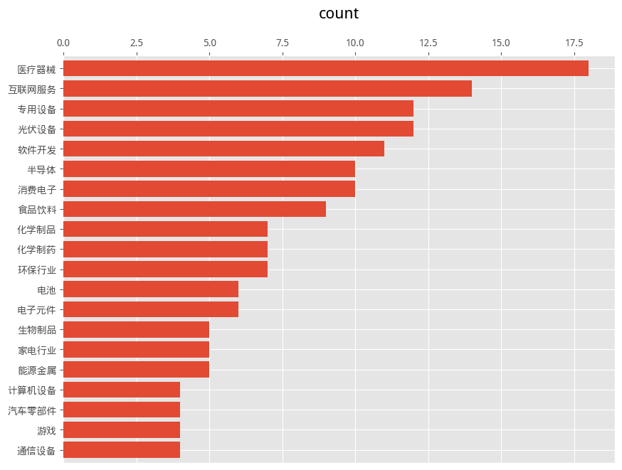

### 最近一年分布

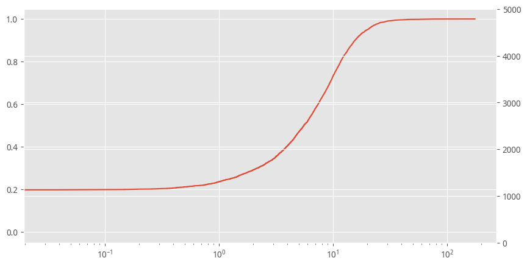

- 大约70%的公司ROE在10%以以下。

## TOP300

```
total: 84 | top 20 : 59.32%
```

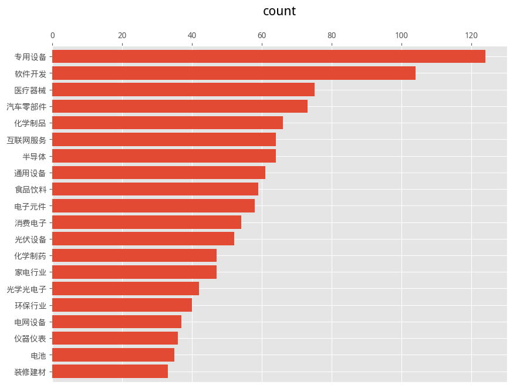

- ROE高的行业，公司普遍比较小。
- 证券和保险业的公司很少上榜，而银行业没有上过。

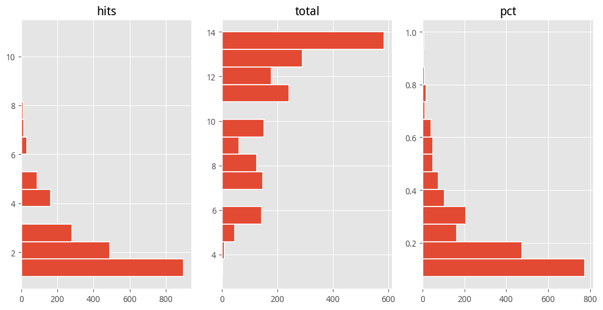

- 上过榜的，还是以老公司为主。但基本上也就上过一两次。
- 保持高的ROE是不太可能的事。

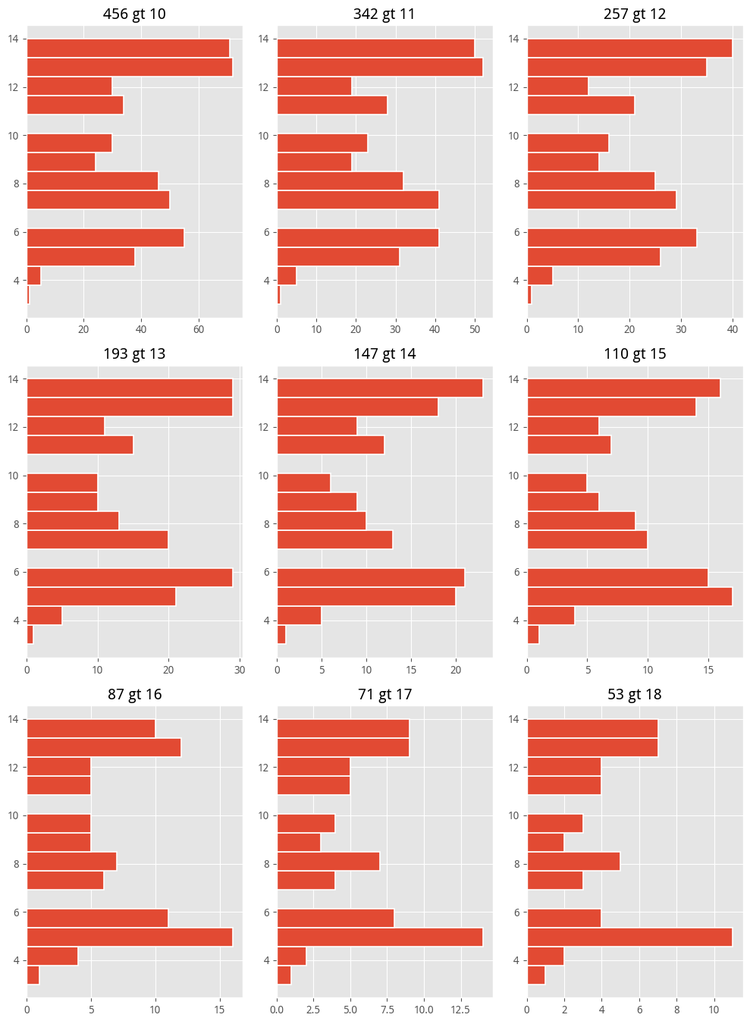

### 每年ROE都超过15%的公司

```
total: 110
```

|  | 1 | 2 | 3 | 4 | 5 | 6 | 7 | 8 | 9 | 10 |
| --- | --- | --- | --- | --- | --- | --- | --- | --- | --- | --- |
| 0 | [招商银行](https://data.eastmoney.com/stockdata/600036.html) 14.00 | [海尔智家](https://data.eastmoney.com/stockdata/600690.html) 14.00 | [格力电器](https://data.eastmoney.com/stockdata/000651.html) 14.00 | [宏发股份](https://data.eastmoney.com/stockdata/600885.html) 14.00 | [片仔癀](https://data.eastmoney.com/stockdata/600436.html) 14.00 | [贵州茅台](https://data.eastmoney.com/stockdata/600519.html) 14.00 | [法拉电子](https://data.eastmoney.com/stockdata/600563.html) 14.00 | [古井贡酒](https://data.eastmoney.com/stockdata/000596.html) 14.00 | [承德露露](https://data.eastmoney.com/stockdata/000848.html) 14.00 | [长春高新](https://data.eastmoney.com/stockdata/000661.html) 14.00 |
| 1 | [海康威视](https://data.eastmoney.com/stockdata/002415.html) 14.00 | [海天味业](https://data.eastmoney.com/stockdata/603288.html) 14.00 | [伊利股份](https://data.eastmoney.com/stockdata/600887.html) 14.00 | [老凤祥](https://data.eastmoney.com/stockdata/600612.html) 14.00 | [洋河股份](https://data.eastmoney.com/stockdata/002304.html) 14.00 | [恩华药业](https://data.eastmoney.com/stockdata/002262.html) 14.00 | [迎驾贡酒](https://data.eastmoney.com/stockdata/603198.html) 13.00 | [浙江鼎力](https://data.eastmoney.com/stockdata/603338.html) 13.00 | [广州酒家](https://data.eastmoney.com/stockdata/603043.html) 13.00 | [元祖股份](https://data.eastmoney.com/stockdata/603886.html) 13.00 |
| 2 | [飞科电器](https://data.eastmoney.com/stockdata/603868.html) 13.00 | [口子窖](https://data.eastmoney.com/stockdata/603589.html) 13.00 | [晨光股份](https://data.eastmoney.com/stockdata/603899.html) 13.00 | [弘亚数控](https://data.eastmoney.com/stockdata/002833.html) 13.00 | [欧派家居](https://data.eastmoney.com/stockdata/603833.html) 13.00 | [周大生](https://data.eastmoney.com/stockdata/002867.html) 13.00 | [中科软](https://data.eastmoney.com/stockdata/603927.html) 13.00 | [新坐标](https://data.eastmoney.com/stockdata/603040.html) 13.00 | [今世缘](https://data.eastmoney.com/stockdata/603369.html) 13.00 | [美的集团](https://data.eastmoney.com/stockdata/000333.html) 13.00 |
| 3 | [凌霄泵业](https://data.eastmoney.com/stockdata/002884.html) 12.00 | [欧普康视](https://data.eastmoney.com/stockdata/300595.html) 12.00 | [亿联网络](https://data.eastmoney.com/stockdata/300628.html) 12.00 | [三人行](https://data.eastmoney.com/stockdata/605168.html) 12.00 | [武汉蓝电](https://data.eastmoney.com/stockdata/830779.html) 12.00 | [新产业](https://data.eastmoney.com/stockdata/300832.html) 12.00 | [广咨国际](https://data.eastmoney.com/stockdata/836892.html) 11.00 | [珀莱雅](https://data.eastmoney.com/stockdata/603605.html) 11.00 | [明阳科技](https://data.eastmoney.com/stockdata/837663.html) 11.00 | [欧晶科技](https://data.eastmoney.com/stockdata/001269.html) 11.00 |
| 4 | [中谷物流](https://data.eastmoney.com/stockdata/603565.html) 11.00 | [嘉友国际](https://data.eastmoney.com/stockdata/603871.html) 11.00 | [志邦家居](https://data.eastmoney.com/stockdata/603801.html) 11.00 | [安克创新](https://data.eastmoney.com/stockdata/300866.html) 10.00 | [骏创科技](https://data.eastmoney.com/stockdata/833533.html) 10.00 | [爱美客](https://data.eastmoney.com/stockdata/300896.html) 10.00 | [思泰克](https://data.eastmoney.com/stockdata/301568.html) 10.00 | [呈和科技](https://data.eastmoney.com/stockdata/688625.html) 10.00 | [曙光数创](https://data.eastmoney.com/stockdata/872808.html) 9.00 | [爱玛科技](https://data.eastmoney.com/stockdata/603529.html) 9.00 |
| 5 | [工业富联](https://data.eastmoney.com/stockdata/601138.html) 9.00 | [公牛集团](https://data.eastmoney.com/stockdata/603195.html) 9.00 | [正海生物](https://data.eastmoney.com/stockdata/300653.html) 9.00 | [中裕科技](https://data.eastmoney.com/stockdata/871694.html) 9.00 | [兴欣新材](https://data.eastmoney.com/stockdata/001358.html) 8.00 | [世茂能源](https://data.eastmoney.com/stockdata/605028.html) 8.00 | [迦南智能](https://data.eastmoney.com/stockdata/300880.html) 8.00 | [共创草坪](https://data.eastmoney.com/stockdata/605099.html) 8.00 | [国子软件](https://data.eastmoney.com/stockdata/872953.html) 8.00 | [德业股份](https://data.eastmoney.com/stockdata/605117.html) 8.00 |
| 6 | [心脉医疗](https://data.eastmoney.com/stockdata/688016.html) 8.00 | [东航物流](https://data.eastmoney.com/stockdata/601156.html) 8.00 | [地铁设计](https://data.eastmoney.com/stockdata/003013.html) 8.00 | [嘉益股份](https://data.eastmoney.com/stockdata/301004.html) 7.00 | [东鹏饮料](https://data.eastmoney.com/stockdata/605499.html) 7.00 | [物产环能](https://data.eastmoney.com/stockdata/603071.html) 7.00 | [恒帅股份](https://data.eastmoney.com/stockdata/300969.html) 7.00 | [欢乐家](https://data.eastmoney.com/stockdata/300997.html) 7.00 | [富佳股份](https://data.eastmoney.com/stockdata/603219.html) 7.00 | [康华生物](https://data.eastmoney.com/stockdata/300841.html) 7.00 |
| 7 | [华利集团](https://data.eastmoney.com/stockdata/300979.html) 7.00 | [怡合达](https://data.eastmoney.com/stockdata/301029.html) 7.00 | [伟创电气](https://data.eastmoney.com/stockdata/688698.html) 7.00 | [万邦医药](https://data.eastmoney.com/stockdata/301520.html) 6.00 | [坤博精工](https://data.eastmoney.com/stockdata/873570.html) 6.00 | [四川黄金](https://data.eastmoney.com/stockdata/001337.html) 6.00 | [紫燕食品](https://data.eastmoney.com/stockdata/603057.html) 6.00 | [英华特](https://data.eastmoney.com/stockdata/301272.html) 6.00 | [常润股份](https://data.eastmoney.com/stockdata/603201.html) 6.00 | [贝隆精密](https://data.eastmoney.com/stockdata/301567.html) 6.00 |
| 8 | [荣旗科技](https://data.eastmoney.com/stockdata/301360.html) 6.00 | [宝立食品](https://data.eastmoney.com/stockdata/603170.html) 6.00 | [敷尔佳](https://data.eastmoney.com/stockdata/301371.html) 6.00 | [慕思股份](https://data.eastmoney.com/stockdata/001323.html) 6.00 | [苏能股份](https://data.eastmoney.com/stockdata/600925.html) 6.00 | [康冠科技](https://data.eastmoney.com/stockdata/001308.html) 6.00 | [比依股份](https://data.eastmoney.com/stockdata/603215.html) 6.00 | [曼恩斯特](https://data.eastmoney.com/stockdata/301325.html) 6.00 | [力聚热能](https://data.eastmoney.com/stockdata/603391.html) 5.00 | [键邦股份](https://data.eastmoney.com/stockdata/603285.html) 5.00 |
| 9 | [科力装备](https://data.eastmoney.com/stockdata/301552.html) 5.00 | [平安电工](https://data.eastmoney.com/stockdata/001359.html) 5.00 | [博实结](https://data.eastmoney.com/stockdata/301608.html) 5.00 | [联域股份](https://data.eastmoney.com/stockdata/001326.html) 5.00 | [瑞迪智驱](https://data.eastmoney.com/stockdata/301596.html) 5.00 | [达梦数据](https://data.eastmoney.com/stockdata/688692.html) 5.00 | [绿联科技](https://data.eastmoney.com/stockdata/301606.html) 5.00 | [星德胜](https://data.eastmoney.com/stockdata/603344.html) 5.00 | [宏鑫科技](https://data.eastmoney.com/stockdata/301539.html) 5.00 | [润本股份](https://data.eastmoney.com/stockdata/603193.html) 5.00 |
| 10 | [索宝蛋白](https://data.eastmoney.com/stockdata/603231.html) 5.00 | [利安科技](https://data.eastmoney.com/stockdata/300784.html) 5.00 | [热威股份](https://data.eastmoney.com/stockdata/603075.html) 5.00 | [北自科技](https://data.eastmoney.com/stockdata/603082.html) 5.00 | [西典新能](https://data.eastmoney.com/stockdata/603312.html) 5.00 | [卓兆点胶](https://data.eastmoney.com/stockdata/873726.html) 4.00 | [龙图光罩](https://data.eastmoney.com/stockdata/688721.html) 4.00 | [三一重能](https://data.eastmoney.com/stockdata/688349.html) 4.00 | [太湖远大](https://data.eastmoney.com/stockdata/920118.html) 4.00 | [艾罗能源](https://data.eastmoney.com/stockdata/688717.html) 3.00 |

### 历年ROE超15%的公司数量和占比

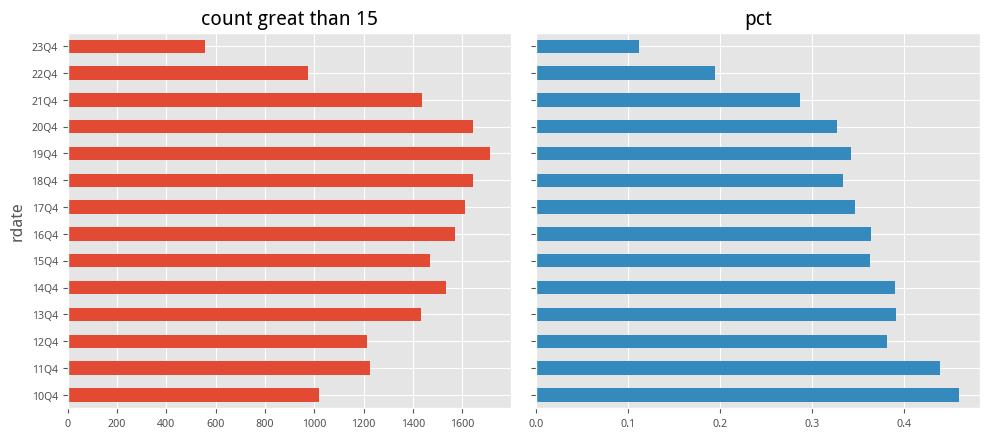

- 数量和占比都在减少。2023年只有12%的公司ROE超过15%。

## 增长情况

- 选择了有6期以上报告的公司，测试其近5年利润增长的夏普指数平均值，从高到低排列。

### 总体情况

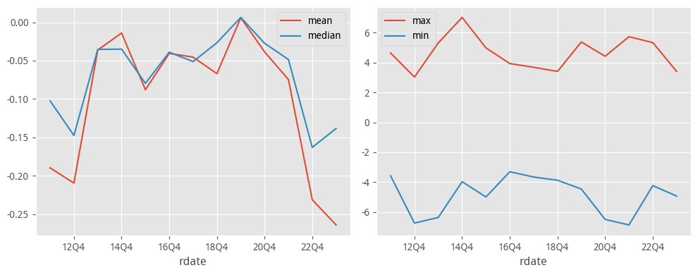

### 增长排名

[output not shown]

- ROE增长速度较快的，看来没有很多熟悉的公司。

### 最近一年增长情况

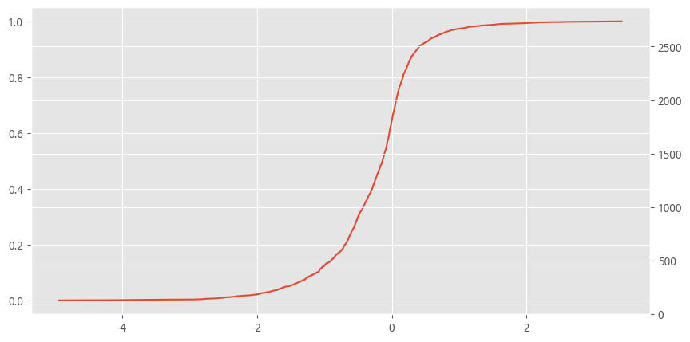

- 超过6成的公司ROE没有增长。

### 夏普指数

- 夏普指数衡量增长的质量，比单纯看增长率要好一点。
- 以下是近五年夏普指数平均后的前300排名。

```
total: 300
```

|  | 1 | 2 | 3 | 4 | 5 | 6 | 7 | 8 | 9 | 10 |
| --- | --- | --- | --- | --- | --- | --- | --- | --- | --- | --- |
| 0 | [硅烷科技](https://data.eastmoney.com/stockdata/838402.html) 1.23 | [无锡鼎邦](https://data.eastmoney.com/stockdata/872931.html) 1.06 | [海昇药业](https://data.eastmoney.com/stockdata/870656.html) 0.94 | [松井股份](https://data.eastmoney.com/stockdata/688157.html) 0.76 | [普门科技](https://data.eastmoney.com/stockdata/688389.html) 0.74 | [三元生物](https://data.eastmoney.com/stockdata/301206.html) 0.71 | [斯达半导](https://data.eastmoney.com/stockdata/603290.html) 0.67 | [新天绿能](https://data.eastmoney.com/stockdata/600956.html) 0.62 | [伟星新材](https://data.eastmoney.com/stockdata/002372.html) 0.62 | [振华科技](https://data.eastmoney.com/stockdata/000733.html) 0.61 |
| 1 | [航天电器](https://data.eastmoney.com/stockdata/002025.html) 0.60 | [天健集团](https://data.eastmoney.com/stockdata/000090.html) 0.57 | [华瓷股份](https://data.eastmoney.com/stockdata/001216.html) 0.56 | [键凯科技](https://data.eastmoney.com/stockdata/688356.html) 0.52 | [爱尔眼科](https://data.eastmoney.com/stockdata/300015.html) 0.52 | [博亚精工](https://data.eastmoney.com/stockdata/300971.html) 0.50 | [南京高科](https://data.eastmoney.com/stockdata/600064.html) 0.50 | [中国国贸](https://data.eastmoney.com/stockdata/600007.html) 0.49 | [科润智控](https://data.eastmoney.com/stockdata/834062.html) 0.49 | [一致魔芋](https://data.eastmoney.com/stockdata/839273.html) 0.48 |
| 2 | [捷佳伟创](https://data.eastmoney.com/stockdata/300724.html) 0.48 | [祖名股份](https://data.eastmoney.com/stockdata/003030.html) 0.48 | [威胜信息](https://data.eastmoney.com/stockdata/688100.html) 0.47 | [恒盛能源](https://data.eastmoney.com/stockdata/605580.html) 0.47 | [华密新材](https://data.eastmoney.com/stockdata/836247.html) 0.47 | [派克新材](https://data.eastmoney.com/stockdata/605123.html) 0.46 | [新媒股份](https://data.eastmoney.com/stockdata/300770.html) 0.45 | [金田股份](https://data.eastmoney.com/stockdata/601609.html) 0.45 | [高铁电气](https://data.eastmoney.com/stockdata/688285.html) 0.45 | [争光股份](https://data.eastmoney.com/stockdata/301092.html) 0.45 |
| 3 | [连城数控](https://data.eastmoney.com/stockdata/835368.html) 0.44 | [传音控股](https://data.eastmoney.com/stockdata/688036.html) 0.44 | [顺控发展](https://data.eastmoney.com/stockdata/003039.html) 0.43 | [迅安科技](https://data.eastmoney.com/stockdata/834950.html) 0.43 | [中控技术](https://data.eastmoney.com/stockdata/688777.html) 0.42 | [盖世食品](https://data.eastmoney.com/stockdata/836826.html) 0.41 | [福蓉科技](https://data.eastmoney.com/stockdata/603327.html) 0.41 | [森麒麟](https://data.eastmoney.com/stockdata/002984.html) 0.40 | [天合光能](https://data.eastmoney.com/stockdata/688599.html) 0.40 | [苏州规划](https://data.eastmoney.com/stockdata/301505.html) 0.40 |
| 4 | [泓禧科技](https://data.eastmoney.com/stockdata/871857.html) 0.40 | [德石股份](https://data.eastmoney.com/stockdata/301158.html) 0.40 | [福立旺](https://data.eastmoney.com/stockdata/688678.html) 0.39 | [博瑞医药](https://data.eastmoney.com/stockdata/688166.html) 0.39 | [三友医疗](https://data.eastmoney.com/stockdata/688085.html) 0.39 | [中国中免](https://data.eastmoney.com/stockdata/601888.html) 0.39 | [扬农化工](https://data.eastmoney.com/stockdata/600486.html) 0.38 | [宝丰能源](https://data.eastmoney.com/stockdata/600989.html) 0.38 | [吉冈精密](https://data.eastmoney.com/stockdata/836720.html) 0.38 | [湖南海利](https://data.eastmoney.com/stockdata/600731.html) 0.36 |
| 5 | [众智科技](https://data.eastmoney.com/stockdata/301361.html) 0.36 | [科思股份](https://data.eastmoney.com/stockdata/300856.html) 0.35 | [新雷能](https://data.eastmoney.com/stockdata/300593.html) 0.35 | [民士达](https://data.eastmoney.com/stockdata/833394.html) 0.35 | [德才股份](https://data.eastmoney.com/stockdata/605287.html) 0.34 | [金博股份](https://data.eastmoney.com/stockdata/688598.html) 0.34 | [芭薇股份](https://data.eastmoney.com/stockdata/837023.html) 0.34 | [远航精密](https://data.eastmoney.com/stockdata/833914.html) 0.34 | [杰创智能](https://data.eastmoney.com/stockdata/301248.html) 0.33 | [嘉泽新能](https://data.eastmoney.com/stockdata/601619.html) 0.33 |
| 6 | [金龙鱼](https://data.eastmoney.com/stockdata/300999.html) 0.32 | [图南股份](https://data.eastmoney.com/stockdata/300855.html) 0.32 | [新强联](https://data.eastmoney.com/stockdata/300850.html) 0.32 | [京新药业](https://data.eastmoney.com/stockdata/002020.html) 0.32 | [乐鑫科技](https://data.eastmoney.com/stockdata/688018.html) 0.32 | [海欣股份](https://data.eastmoney.com/stockdata/600851.html) 0.32 | [伟明环保](https://data.eastmoney.com/stockdata/603568.html) 0.31 | [迈为股份](https://data.eastmoney.com/stockdata/300751.html) 0.31 | [鸿智科技](https://data.eastmoney.com/stockdata/870726.html) 0.30 | [驰诚股份](https://data.eastmoney.com/stockdata/834407.html) 0.30 |
| 7 | [佳禾智能](https://data.eastmoney.com/stockdata/300793.html) 0.30 | [行动教育](https://data.eastmoney.com/stockdata/605098.html) 0.29 | [新风光](https://data.eastmoney.com/stockdata/688663.html) 0.29 | [久立特材](https://data.eastmoney.com/stockdata/002318.html) 0.29 | [晶科科技](https://data.eastmoney.com/stockdata/601778.html) 0.29 | [征和工业](https://data.eastmoney.com/stockdata/003033.html) 0.29 | [百胜智能](https://data.eastmoney.com/stockdata/301083.html) 0.28 | [同济科技](https://data.eastmoney.com/stockdata/600846.html) 0.28 | [芯源微](https://data.eastmoney.com/stockdata/688037.html) 0.28 | [华金资本](https://data.eastmoney.com/stockdata/000532.html) 0.28 |
| 8 | [天元智能](https://data.eastmoney.com/stockdata/603273.html) 0.28 | [洪城环境](https://data.eastmoney.com/stockdata/600461.html) 0.27 | [联环药业](https://data.eastmoney.com/stockdata/600513.html) 0.27 | [八亿时空](https://data.eastmoney.com/stockdata/688181.html) 0.27 | [长龄液压](https://data.eastmoney.com/stockdata/605389.html) 0.27 | [奇正藏药](https://data.eastmoney.com/stockdata/002287.html) 0.27 | [汇通能源](https://data.eastmoney.com/stockdata/600605.html) 0.27 | [邦德股份](https://data.eastmoney.com/stockdata/838171.html) 0.26 | [平高电气](https://data.eastmoney.com/stockdata/600312.html) 0.26 | [合盛硅业](https://data.eastmoney.com/stockdata/603260.html) 0.26 |
| 9 | [贝特瑞](https://data.eastmoney.com/stockdata/835185.html) 0.26 | [安德利](https://data.eastmoney.com/stockdata/605198.html) 0.26 | [洪通燃气](https://data.eastmoney.com/stockdata/605169.html) 0.26 | [华翔股份](https://data.eastmoney.com/stockdata/603112.html) 0.26 | [科安达](https://data.eastmoney.com/stockdata/002972.html) 0.26 | [普洛药业](https://data.eastmoney.com/stockdata/000739.html) 0.26 | [福能股份](https://data.eastmoney.com/stockdata/600483.html) 0.26 | [元道通信](https://data.eastmoney.com/stockdata/301139.html) 0.26 | [天能股份](https://data.eastmoney.com/stockdata/688819.html) 0.26 | [新奥股份](https://data.eastmoney.com/stockdata/600803.html) 0.26 |
| 10 | [光威复材](https://data.eastmoney.com/stockdata/300699.html) 0.25 | [华维设计](https://data.eastmoney.com/stockdata/833427.html) 0.25 | [睿创微纳](https://data.eastmoney.com/stockdata/688002.html) 0.25 | [蓝特光学](https://data.eastmoney.com/stockdata/688127.html) 0.25 | [大胜达](https://data.eastmoney.com/stockdata/603687.html) 0.25 | [依依股份](https://data.eastmoney.com/stockdata/001206.html) 0.25 | [美瑞新材](https://data.eastmoney.com/stockdata/300848.html) 0.25 | [智洋创新](https://data.eastmoney.com/stockdata/688191.html) 0.25 | [璞泰来](https://data.eastmoney.com/stockdata/603659.html) 0.25 | [华泰股份](https://data.eastmoney.com/stockdata/600308.html) 0.25 |
| 11 | [三友联众](https://data.eastmoney.com/stockdata/300932.html) 0.25 | [中天火箭](https://data.eastmoney.com/stockdata/003009.html) 0.24 | [秋田微](https://data.eastmoney.com/stockdata/300939.html) 0.24 | [中金辐照](https://data.eastmoney.com/stockdata/300962.html) 0.24 | [力王股份](https://data.eastmoney.com/stockdata/831627.html) 0.24 | [密封科技](https://data.eastmoney.com/stockdata/301020.html) 0.24 | [济川药业](https://data.eastmoney.com/stockdata/600566.html) 0.24 | [东方碳素](https://data.eastmoney.com/stockdata/832175.html) 0.24 | [未来电器](https://data.eastmoney.com/stockdata/301386.html) 0.24 | [运达股份](https://data.eastmoney.com/stockdata/300772.html) 0.24 |
| 12 | [景津装备](https://data.eastmoney.com/stockdata/603279.html) 0.23 | [浪潮信息](https://data.eastmoney.com/stockdata/000977.html) 0.23 | [金鹰股份](https://data.eastmoney.com/stockdata/600232.html) 0.23 | [万胜智能](https://data.eastmoney.com/stockdata/300882.html) 0.23 | [海大集团](https://data.eastmoney.com/stockdata/002311.html) 0.22 | [利仁科技](https://data.eastmoney.com/stockdata/001259.html) 0.22 | [百洋医药](https://data.eastmoney.com/stockdata/301015.html) 0.22 | [拓新药业](https://data.eastmoney.com/stockdata/301089.html) 0.22 | [龙磁科技](https://data.eastmoney.com/stockdata/300835.html) 0.22 | [盛帮股份](https://data.eastmoney.com/stockdata/301233.html) 0.21 |
| 13 | [迈瑞医疗](https://data.eastmoney.com/stockdata/300760.html) 0.21 | [开普云](https://data.eastmoney.com/stockdata/688228.html) 0.21 | [凌玮科技](https://data.eastmoney.com/stockdata/301373.html) 0.21 | [锋尚文化](https://data.eastmoney.com/stockdata/300860.html) 0.21 | [上海临港](https://data.eastmoney.com/stockdata/600848.html) 0.21 | [冠农股份](https://data.eastmoney.com/stockdata/600251.html) 0.21 | [浩欧博](https://data.eastmoney.com/stockdata/688656.html) 0.21 | [万德股份](https://data.eastmoney.com/stockdata/836419.html) 0.20 | [中国海防](https://data.eastmoney.com/stockdata/600764.html) 0.20 | [东方电子](https://data.eastmoney.com/stockdata/000682.html) 0.20 |
| 14 | [雅葆轩](https://data.eastmoney.com/stockdata/870357.html) 0.20 | [太湖雪](https://data.eastmoney.com/stockdata/838262.html) 0.20 | [深南电路](https://data.eastmoney.com/stockdata/002916.html) 0.20 | [广电计量](https://data.eastmoney.com/stockdata/002967.html) 0.20 | [英科医疗](https://data.eastmoney.com/stockdata/300677.html) 0.20 | [汉商集团](https://data.eastmoney.com/stockdata/600774.html) 0.20 | [财通证券](https://data.eastmoney.com/stockdata/601108.html) 0.19 | [易点天下](https://data.eastmoney.com/stockdata/301171.html) 0.19 | [德业股份](https://data.eastmoney.com/stockdata/605117.html) 0.19 | [严牌股份](https://data.eastmoney.com/stockdata/301081.html) 0.19 |
| 15 | [凯腾精工](https://data.eastmoney.com/stockdata/871553.html) 0.19 | [新芝生物](https://data.eastmoney.com/stockdata/430685.html) 0.18 | [紫光国微](https://data.eastmoney.com/stockdata/002049.html) 0.18 | [容百科技](https://data.eastmoney.com/stockdata/688005.html) 0.18 | [普利制药](https://data.eastmoney.com/stockdata/300630.html) 0.18 | [中国铁建](https://data.eastmoney.com/stockdata/601186.html) 0.18 | [亚华电子](https://data.eastmoney.com/stockdata/301337.html) 0.18 | [顺丰控股](https://data.eastmoney.com/stockdata/002352.html) 0.18 | [珠江啤酒](https://data.eastmoney.com/stockdata/002461.html) 0.18 | [京北方](https://data.eastmoney.com/stockdata/002987.html) 0.18 |
| 16 | [钢研高纳](https://data.eastmoney.com/stockdata/300034.html) 0.18 | [轻纺城](https://data.eastmoney.com/stockdata/600790.html) 0.18 | [健民集团](https://data.eastmoney.com/stockdata/600976.html) 0.18 | [羚锐制药](https://data.eastmoney.com/stockdata/600285.html) 0.17 | [斯菱股份](https://data.eastmoney.com/stockdata/301550.html) 0.17 | [创业环保](https://data.eastmoney.com/stockdata/600874.html) 0.17 | [青矩技术](https://data.eastmoney.com/stockdata/836208.html) 0.17 | [利通科技](https://data.eastmoney.com/stockdata/832225.html) 0.17 | [紫光股份](https://data.eastmoney.com/stockdata/000938.html) 0.17 | [东利机械](https://data.eastmoney.com/stockdata/301298.html) 0.17 |
| 17 | [贵州燃气](https://data.eastmoney.com/stockdata/600903.html) 0.17 | [视觉中国](https://data.eastmoney.com/stockdata/000681.html) 0.17 | [鲁阳节能](https://data.eastmoney.com/stockdata/002088.html) 0.17 | [江天化学](https://data.eastmoney.com/stockdata/300927.html) 0.17 | [恒立钻具](https://data.eastmoney.com/stockdata/836942.html) 0.17 | [立昂微](https://data.eastmoney.com/stockdata/605358.html) 0.17 | [广东建工](https://data.eastmoney.com/stockdata/002060.html) 0.17 | [中国建筑](https://data.eastmoney.com/stockdata/601668.html) 0.17 | [千金药业](https://data.eastmoney.com/stockdata/600479.html) 0.17 | [华鲁恒升](https://data.eastmoney.com/stockdata/600426.html) 0.17 |
| 18 | [海澜之家](https://data.eastmoney.com/stockdata/600398.html) 0.16 | [国睿科技](https://data.eastmoney.com/stockdata/600562.html) 0.16 | [泰山石油](https://data.eastmoney.com/stockdata/000554.html) 0.16 | [新亚强](https://data.eastmoney.com/stockdata/603155.html) 0.16 | [奕瑞科技](https://data.eastmoney.com/stockdata/688301.html) 0.16 | [和远气体](https://data.eastmoney.com/stockdata/002971.html) 0.16 | [巴比食品](https://data.eastmoney.com/stockdata/605338.html) 0.16 | [惠同新材](https://data.eastmoney.com/stockdata/833751.html) 0.16 | [电科数字](https://data.eastmoney.com/stockdata/600850.html) 0.16 | [通易航天](https://data.eastmoney.com/stockdata/871642.html) 0.16 |
| 19 | [华安证券](https://data.eastmoney.com/stockdata/600909.html) 0.16 | [花溪科技](https://data.eastmoney.com/stockdata/872895.html) 0.15 | [康龙化成](https://data.eastmoney.com/stockdata/300759.html) 0.15 | [亿纬锂能](https://data.eastmoney.com/stockdata/300014.html) 0.15 | [利尔化学](https://data.eastmoney.com/stockdata/002258.html) 0.15 | [茂莱光学](https://data.eastmoney.com/stockdata/688502.html) 0.15 | [华峰铝业](https://data.eastmoney.com/stockdata/601702.html) 0.15 | [联泰环保](https://data.eastmoney.com/stockdata/603797.html) 0.15 | [优宁维](https://data.eastmoney.com/stockdata/301166.html) 0.15 | [广弘控股](https://data.eastmoney.com/stockdata/000529.html) 0.15 |
| 20 | [三峰环境](https://data.eastmoney.com/stockdata/601827.html) 0.15 | [富安娜](https://data.eastmoney.com/stockdata/002327.html) 0.14 | [西部创业](https://data.eastmoney.com/stockdata/000557.html) 0.14 | [明阳智能](https://data.eastmoney.com/stockdata/601615.html) 0.14 | [长春高新](https://data.eastmoney.com/stockdata/000661.html) 0.14 | [四川路桥](https://data.eastmoney.com/stockdata/600039.html) 0.14 | [美硕科技](https://data.eastmoney.com/stockdata/301295.html) 0.14 | [恒进感应](https://data.eastmoney.com/stockdata/838670.html) 0.14 | [华测检测](https://data.eastmoney.com/stockdata/300012.html) 0.14 | [建业股份](https://data.eastmoney.com/stockdata/603948.html) 0.14 |
| 21 | [华新环保](https://data.eastmoney.com/stockdata/301265.html) 0.14 | [中科美菱](https://data.eastmoney.com/stockdata/835892.html) 0.14 | [立讯精密](https://data.eastmoney.com/stockdata/002475.html) 0.14 | [汇隆新材](https://data.eastmoney.com/stockdata/301057.html) 0.14 | [博迅生物](https://data.eastmoney.com/stockdata/836504.html) 0.14 | [博俊科技](https://data.eastmoney.com/stockdata/300926.html) 0.14 | [瑞茂通](https://data.eastmoney.com/stockdata/600180.html) 0.14 | [新宙邦](https://data.eastmoney.com/stockdata/300037.html) 0.14 | [启明星辰](https://data.eastmoney.com/stockdata/002439.html) 0.14 | [同兴环保](https://data.eastmoney.com/stockdata/003027.html) 0.14 |
| 22 | [瑞奇智造](https://data.eastmoney.com/stockdata/833781.html) 0.14 | [宝武镁业](https://data.eastmoney.com/stockdata/002182.html) 0.13 | [三峡能源](https://data.eastmoney.com/stockdata/600905.html) 0.13 | [海天精工](https://data.eastmoney.com/stockdata/601882.html) 0.13 | [江苏新能](https://data.eastmoney.com/stockdata/603693.html) 0.13 | [科源制药](https://data.eastmoney.com/stockdata/301281.html) 0.13 | [联创光电](https://data.eastmoney.com/stockdata/600363.html) 0.13 | [瑞可达](https://data.eastmoney.com/stockdata/688800.html) 0.13 | [协昌科技](https://data.eastmoney.com/stockdata/301418.html) 0.13 | [川投能源](https://data.eastmoney.com/stockdata/600674.html) 0.13 |
| 23 | [九鼎投资](https://data.eastmoney.com/stockdata/600053.html) 0.13 | [吉比特](https://data.eastmoney.com/stockdata/603444.html) 0.13 | [德瑞锂电](https://data.eastmoney.com/stockdata/833523.html) 0.13 | [节能风电](https://data.eastmoney.com/stockdata/601016.html) 0.13 | [科创新材](https://data.eastmoney.com/stockdata/833580.html) 0.13 | [球冠电缆](https://data.eastmoney.com/stockdata/834682.html) 0.13 | [盈峰环境](https://data.eastmoney.com/stockdata/000967.html) 0.13 | [柏星龙](https://data.eastmoney.com/stockdata/833075.html) 0.12 | [同花顺](https://data.eastmoney.com/stockdata/300033.html) 0.12 | [恒勃股份](https://data.eastmoney.com/stockdata/301225.html) 0.12 |
| 24 | [利安隆](https://data.eastmoney.com/stockdata/300596.html) 0.12 | [江丰电子](https://data.eastmoney.com/stockdata/300666.html) 0.12 | [漫步者](https://data.eastmoney.com/stockdata/002351.html) 0.12 | [中远海科](https://data.eastmoney.com/stockdata/002401.html) 0.12 | [沃顿科技](https://data.eastmoney.com/stockdata/000920.html) 0.12 | [昊帆生物](https://data.eastmoney.com/stockdata/301393.html) 0.12 | [和而泰](https://data.eastmoney.com/stockdata/002402.html) 0.12 | [艾融软件](https://data.eastmoney.com/stockdata/830799.html) 0.12 | [隆华新材](https://data.eastmoney.com/stockdata/301149.html) 0.12 | [金力永磁](https://data.eastmoney.com/stockdata/300748.html) 0.12 |
| 25 | [双箭股份](https://data.eastmoney.com/stockdata/002381.html) 0.12 | [福达合金](https://data.eastmoney.com/stockdata/603045.html) 0.12 | [同惠电子](https://data.eastmoney.com/stockdata/833509.html) 0.12 | [新化股份](https://data.eastmoney.com/stockdata/603867.html) 0.12 | [瑞星股份](https://data.eastmoney.com/stockdata/836717.html) 0.12 | [新华制药](https://data.eastmoney.com/stockdata/000756.html) 0.12 | [大商股份](https://data.eastmoney.com/stockdata/600694.html) 0.11 | [舍得酒业](https://data.eastmoney.com/stockdata/600702.html) 0.11 | [高测股份](https://data.eastmoney.com/stockdata/688556.html) 0.11 | [通威股份](https://data.eastmoney.com/stockdata/600438.html) 0.11 |
| 26 | [龙建股份](https://data.eastmoney.com/stockdata/600853.html) 0.11 | [华丰股份](https://data.eastmoney.com/stockdata/605100.html) 0.11 | [中航光电](https://data.eastmoney.com/stockdata/002179.html) 0.11 | [陆家嘴](https://data.eastmoney.com/stockdata/600663.html) 0.11 | [浙江美大](https://data.eastmoney.com/stockdata/002677.html) 0.11 | [山东药玻](https://data.eastmoney.com/stockdata/600529.html) 0.11 | [硅宝科技](https://data.eastmoney.com/stockdata/300019.html) 0.11 | [海天股份](https://data.eastmoney.com/stockdata/603759.html) 0.11 | [建邦科技](https://data.eastmoney.com/stockdata/837242.html) 0.11 | [申菱环境](https://data.eastmoney.com/stockdata/301018.html) 0.11 |
| 27 | [特宝生物](https://data.eastmoney.com/stockdata/688278.html) 0.11 | [中创股份](https://data.eastmoney.com/stockdata/688695.html) 0.11 | [联瑞新材](https://data.eastmoney.com/stockdata/688300.html) 0.11 | [阿科力](https://data.eastmoney.com/stockdata/603722.html) 0.10 | [太阳能](https://data.eastmoney.com/stockdata/000591.html) 0.10 | [联美控股](https://data.eastmoney.com/stockdata/600167.html) 0.10 | [苏州银行](https://data.eastmoney.com/stockdata/002966.html) 0.10 | [无锡晶海](https://data.eastmoney.com/stockdata/836547.html) 0.10 | [联合光电](https://data.eastmoney.com/stockdata/300691.html) 0.10 | [创识科技](https://data.eastmoney.com/stockdata/300941.html) 0.10 |
| 28 | [众诚科技](https://data.eastmoney.com/stockdata/835207.html) 0.10 | [爱建集团](https://data.eastmoney.com/stockdata/600643.html) 0.10 | [望变电气](https://data.eastmoney.com/stockdata/603191.html) 0.10 | [华康股份](https://data.eastmoney.com/stockdata/605077.html) 0.10 | [江山股份](https://data.eastmoney.com/stockdata/600389.html) 0.10 | [诚志股份](https://data.eastmoney.com/stockdata/000990.html) 0.10 | [外服控股](https://data.eastmoney.com/stockdata/600662.html) 0.10 | [三孚股份](https://data.eastmoney.com/stockdata/603938.html) 0.10 | [伯特利](https://data.eastmoney.com/stockdata/603596.html) 0.09 | [新华文轩](https://data.eastmoney.com/stockdata/601811.html) 0.09 |
| 29 | [林海股份](https://data.eastmoney.com/stockdata/600099.html) 0.09 | [垒知集团](https://data.eastmoney.com/stockdata/002398.html) 0.09 | [西藏药业](https://data.eastmoney.com/stockdata/600211.html) 0.09 | [中持股份](https://data.eastmoney.com/stockdata/603903.html) 0.09 | [山东玻纤](https://data.eastmoney.com/stockdata/605006.html) 0.09 | [北方国际](https://data.eastmoney.com/stockdata/000065.html) 0.09 | [苑东生物](https://data.eastmoney.com/stockdata/688513.html) 0.09 | [众望布艺](https://data.eastmoney.com/stockdata/605003.html) 0.09 | [众源新材](https://data.eastmoney.com/stockdata/603527.html) 0.09 | [嘉事堂](https://data.eastmoney.com/stockdata/002462.html) 0.09 |

## 金额和增长

- ROE曾经进入过前300,同时夏普指数近五年平均也进入前300。

```
total: 114
```

|  | 1 | 2 | 3 | 4 | 5 | 6 | 7 | 8 | 9 | 10 |
| --- | --- | --- | --- | --- | --- | --- | --- | --- | --- | --- |
| 0 | [硅烷科技](https://data.eastmoney.com/stockdata/838402.html) 1.23 | [无锡鼎邦](https://data.eastmoney.com/stockdata/872931.html) 1.06 | [海昇药业](https://data.eastmoney.com/stockdata/870656.html) 0.94 | [普门科技](https://data.eastmoney.com/stockdata/688389.html) 0.74 | [三元生物](https://data.eastmoney.com/stockdata/301206.html) 0.71 | [伟星新材](https://data.eastmoney.com/stockdata/002372.html) 0.62 | [振华科技](https://data.eastmoney.com/stockdata/000733.html) 0.61 | [捷佳伟创](https://data.eastmoney.com/stockdata/300724.html) 0.48 | [恒盛能源](https://data.eastmoney.com/stockdata/605580.html) 0.47 | [威胜信息](https://data.eastmoney.com/stockdata/688100.html) 0.47 |
| 1 | [争光股份](https://data.eastmoney.com/stockdata/301092.html) 0.45 | [新媒股份](https://data.eastmoney.com/stockdata/300770.html) 0.45 | [连城数控](https://data.eastmoney.com/stockdata/835368.html) 0.44 | [传音控股](https://data.eastmoney.com/stockdata/688036.html) 0.44 | [迅安科技](https://data.eastmoney.com/stockdata/834950.html) 0.43 | [盖世食品](https://data.eastmoney.com/stockdata/836826.html) 0.41 | [天合光能](https://data.eastmoney.com/stockdata/688599.html) 0.40 | [中国中免](https://data.eastmoney.com/stockdata/601888.html) 0.39 | [吉冈精密](https://data.eastmoney.com/stockdata/836720.html) 0.38 | [众智科技](https://data.eastmoney.com/stockdata/301361.html) 0.36 |
| 2 | [科思股份](https://data.eastmoney.com/stockdata/300856.html) 0.35 | [金博股份](https://data.eastmoney.com/stockdata/688598.html) 0.34 | [芭薇股份](https://data.eastmoney.com/stockdata/837023.html) 0.34 | [图南股份](https://data.eastmoney.com/stockdata/300855.html) 0.32 | [新强联](https://data.eastmoney.com/stockdata/300850.html) 0.32 | [乐鑫科技](https://data.eastmoney.com/stockdata/688018.html) 0.32 | [迈为股份](https://data.eastmoney.com/stockdata/300751.html) 0.31 | [伟明环保](https://data.eastmoney.com/stockdata/603568.html) 0.31 | [鸿智科技](https://data.eastmoney.com/stockdata/870726.html) 0.30 | [行动教育](https://data.eastmoney.com/stockdata/605098.html) 0.29 |
| 3 | [久立特材](https://data.eastmoney.com/stockdata/002318.html) 0.29 | [天元智能](https://data.eastmoney.com/stockdata/603273.html) 0.28 | [长龄液压](https://data.eastmoney.com/stockdata/605389.html) 0.27 | [邦德股份](https://data.eastmoney.com/stockdata/838171.html) 0.26 | [贝特瑞](https://data.eastmoney.com/stockdata/835185.html) 0.26 | [合盛硅业](https://data.eastmoney.com/stockdata/603260.html) 0.26 | [新奥股份](https://data.eastmoney.com/stockdata/600803.html) 0.26 | [天能股份](https://data.eastmoney.com/stockdata/688819.html) 0.26 | [智洋创新](https://data.eastmoney.com/stockdata/688191.html) 0.25 | [美瑞新材](https://data.eastmoney.com/stockdata/300848.html) 0.25 |
| 4 | [蓝特光学](https://data.eastmoney.com/stockdata/688127.html) 0.25 | [华维设计](https://data.eastmoney.com/stockdata/833427.html) 0.25 | [璞泰来](https://data.eastmoney.com/stockdata/603659.html) 0.25 | [密封科技](https://data.eastmoney.com/stockdata/301020.html) 0.24 | [济川药业](https://data.eastmoney.com/stockdata/600566.html) 0.24 | [东方碳素](https://data.eastmoney.com/stockdata/832175.html) 0.24 | [景津装备](https://data.eastmoney.com/stockdata/603279.html) 0.23 | [万胜智能](https://data.eastmoney.com/stockdata/300882.html) 0.23 | [利仁科技](https://data.eastmoney.com/stockdata/001259.html) 0.22 | [百洋医药](https://data.eastmoney.com/stockdata/301015.html) 0.22 |
| 5 | [迈瑞医疗](https://data.eastmoney.com/stockdata/300760.html) 0.21 | [开普云](https://data.eastmoney.com/stockdata/688228.html) 0.21 | [锋尚文化](https://data.eastmoney.com/stockdata/300860.html) 0.21 | [冠农股份](https://data.eastmoney.com/stockdata/600251.html) 0.21 | [浩欧博](https://data.eastmoney.com/stockdata/688656.html) 0.21 | [雅葆轩](https://data.eastmoney.com/stockdata/870357.html) 0.20 | [英科医疗](https://data.eastmoney.com/stockdata/300677.html) 0.20 | [易点天下](https://data.eastmoney.com/stockdata/301171.html) 0.19 | [德业股份](https://data.eastmoney.com/stockdata/605117.html) 0.19 | [新芝生物](https://data.eastmoney.com/stockdata/430685.html) 0.18 |
| 6 | [紫光国微](https://data.eastmoney.com/stockdata/002049.html) 0.18 | [健民集团](https://data.eastmoney.com/stockdata/600976.html) 0.18 | [斯菱股份](https://data.eastmoney.com/stockdata/301550.html) 0.17 | [视觉中国](https://data.eastmoney.com/stockdata/000681.html) 0.17 | [利通科技](https://data.eastmoney.com/stockdata/832225.html) 0.17 | [青矩技术](https://data.eastmoney.com/stockdata/836208.html) 0.17 | [羚锐制药](https://data.eastmoney.com/stockdata/600285.html) 0.17 | [恒立钻具](https://data.eastmoney.com/stockdata/836942.html) 0.17 | [华鲁恒升](https://data.eastmoney.com/stockdata/600426.html) 0.17 | [海澜之家](https://data.eastmoney.com/stockdata/600398.html) 0.16 |
| 7 | [新亚强](https://data.eastmoney.com/stockdata/603155.html) 0.16 | [通易航天](https://data.eastmoney.com/stockdata/871642.html) 0.16 | [利尔化学](https://data.eastmoney.com/stockdata/002258.html) 0.15 | [华峰铝业](https://data.eastmoney.com/stockdata/601702.html) 0.15 | [优宁维](https://data.eastmoney.com/stockdata/301166.html) 0.15 | [广弘控股](https://data.eastmoney.com/stockdata/000529.html) 0.15 | [瑞奇智造](https://data.eastmoney.com/stockdata/833781.html) 0.14 | [四川路桥](https://data.eastmoney.com/stockdata/600039.html) 0.14 | [美硕科技](https://data.eastmoney.com/stockdata/301295.html) 0.14 | [恒进感应](https://data.eastmoney.com/stockdata/838670.html) 0.14 |
| 8 | [建业股份](https://data.eastmoney.com/stockdata/603948.html) 0.14 | [中科美菱](https://data.eastmoney.com/stockdata/835892.html) 0.14 | [立讯精密](https://data.eastmoney.com/stockdata/002475.html) 0.14 | [博迅生物](https://data.eastmoney.com/stockdata/836504.html) 0.14 | [博俊科技](https://data.eastmoney.com/stockdata/300926.html) 0.14 | [瑞茂通](https://data.eastmoney.com/stockdata/600180.html) 0.14 | [同兴环保](https://data.eastmoney.com/stockdata/003027.html) 0.14 | [长春高新](https://data.eastmoney.com/stockdata/000661.html) 0.14 | [宝武镁业](https://data.eastmoney.com/stockdata/002182.html) 0.13 | [海天精工](https://data.eastmoney.com/stockdata/601882.html) 0.13 |
| 9 | [科源制药](https://data.eastmoney.com/stockdata/301281.html) 0.13 | [协昌科技](https://data.eastmoney.com/stockdata/301418.html) 0.13 | [九鼎投资](https://data.eastmoney.com/stockdata/600053.html) 0.13 | [吉比特](https://data.eastmoney.com/stockdata/603444.html) 0.13 | [德瑞锂电](https://data.eastmoney.com/stockdata/833523.html) 0.13 | [昊帆生物](https://data.eastmoney.com/stockdata/301393.html) 0.12 | [艾融软件](https://data.eastmoney.com/stockdata/830799.html) 0.12 | [金力永磁](https://data.eastmoney.com/stockdata/300748.html) 0.12 | [同花顺](https://data.eastmoney.com/stockdata/300033.html) 0.12 | [舍得酒业](https://data.eastmoney.com/stockdata/600702.html) 0.11 |
| 10 | [高测股份](https://data.eastmoney.com/stockdata/688556.html) 0.11 | [通威股份](https://data.eastmoney.com/stockdata/600438.html) 0.11 | [浙江美大](https://data.eastmoney.com/stockdata/002677.html) 0.11 | [建邦科技](https://data.eastmoney.com/stockdata/837242.html) 0.11 | [特宝生物](https://data.eastmoney.com/stockdata/688278.html) 0.11 | [中创股份](https://data.eastmoney.com/stockdata/688695.html) 0.11 | [无锡晶海](https://data.eastmoney.com/stockdata/836547.html) 0.10 | [江山股份](https://data.eastmoney.com/stockdata/600389.html) 0.10 | [华康股份](https://data.eastmoney.com/stockdata/605077.html) 0.10 | [三孚股份](https://data.eastmoney.com/stockdata/603938.html) 0.10 |
| 11 | [创识科技](https://data.eastmoney.com/stockdata/300941.html) 0.10 | [伯特利](https://data.eastmoney.com/stockdata/603596.html) 0.09 | [西藏药业](https://data.eastmoney.com/stockdata/600211.html) 0.09 | [众望布艺](https://data.eastmoney.com/stockdata/605003.html) 0.09 | nan | nan | nan | nan | nan | nan |

```
total: 114 | banks: 0 | non-banks: 114
```

|  | cname | sharpe_r5 |
| --- | --- | --- |
| 0 | 硅烷科技 | 1.23 |
| 1 | 无锡鼎邦 | 1.06 |
| 2 | 海昇药业 | 0.94 |
| 4 | 普门科技 | 0.74 |
| 5 | 三元生物 | 0.71 |
| ... | ... | ... |
| 279 | 三孚股份 | 0.10 |
| 287 | 创识科技 | 0.10 |
| 288 | 伯特利 | 0.09 |
| 292 | 西藏药业 | 0.09 |
| 297 | 众望布艺 | 0.09 |

114 rows × 2 columns

- ROE高，同时ROE平均增长还高的，果然没有任何大金融。